# lab8 part1

1. In this part, firstly, I use the function random_split to choose 5 different dataset size. The size are 250, 500, 750, 1000, 5000 respectively. And the test set size is set to be 10000, which is the full test size. Train_a ~ Train_e represent the five train set.

```python
import torch
import torch.nn as nn
import torchvision
import torchvision.transforms as transforms


# Device configuration
device = torch.device('cuda:0' if torch.cuda.is_available() else 'cpu')

# Hyper parameters
num_epochs = 5
num_classes = 10
batch_size = 100
learning_rate = 0.001

# MNIST dataset
#train_dataset = torchvision.datasets.MNIST(root='./data/',
#                                           train=True,
#                                           transform=transforms.ToTensor(),
#                                           download=True)

#test_dataset = torchvision.datasets.MNIST(root='./data/',
#                                         train=False,
#                                          transform=transforms.ToTensor())
train_a, temp_a = torch.utils.data.random_split(torchvision.datasets.MNIST(root='./data/',
                                                                        train = True,
                                                                        transform=transforms.ToTensor(),download=True),
                                                                        [250,59750])
train_b, temp_b = torch.utils.data.random_split(torchvision.datasets.MNIST(root='./data/',
                                                                        train = True,
                                                                        transform=transforms.ToTensor(),download=True),
                                                                        [500,59500])
train_c, temp_c = torch.utils.data.random_split(torchvision.datasets.MNIST(root='./data/',
                                                                        train = True,
                                                                        transform=transforms.ToTensor(),download=True),
                                                                        [750,59250])
train_d, temp_d = torch.utils.data.random_split(torchvision.datasets.MNIST(root='./data/',
                                                                        train = True,
                                                                        transform=transforms.ToTensor(),download=True),
                                                                        [1000,59000])
train_e, temp_e = torch.utils.data.random_split(torchvision.datasets.MNIST(root='./data/',
                                                                        train = True,
                                                                        transform=transforms.ToTensor(),download=True),
                                                                        [5000,55000])
test_dataset, temp_dataset = torch.utils.data.random_split(torchvision.datasets.MNIST(root='./data/',
                                                                        train = False,
                                                                        transform=transforms.ToTensor(),download=True),
                                                                        [10000,0])
```

1. Then I load the train dataset into the Data_loader

```python
# Data loader
train_loader_a = torch.utils.data.DataLoader(dataset=train_a,
                                           batch_size=batch_size,
                                           shuffle=True)
train_loader_b = torch.utils.data.DataLoader(dataset=train_b,
                                           batch_size=batch_size,
                                           shuffle=True)
train_loader_c = torch.utils.data.DataLoader(dataset=train_c,
                                           batch_size=batch_size,
                                           shuffle=True)
train_loader_d = torch.utils.data.DataLoader(dataset=train_d,
                                           batch_size=batch_size,
                                           shuffle=True)
train_loader_e = torch.utils.data.DataLoader(dataset=train_e,
                                           batch_size=batch_size,
                                           shuffle=True)
test_loader = torch.utils.data.DataLoader(dataset=test_dataset,
                                           batch_size=batch_size,
                                           shuffle=True)
```

```python
print(len(train_loader_a))
print(len(train_loader_b))
print(len(train_loader_c))
print(len(train_loader_d))
print(len(train_loader_e))
print(len(test_loader))
```

```
3
5
8
10
50
100
```

1. Construct the two-layer convolutional neural network

```python
# Convolutional neural network (two convolutional layers)
class ConvNet(nn.Module):
    def __init__(self, num_classes=10):
        super(ConvNet, self).__init__()
        self.layer1 = nn.Sequential(
            nn.Conv2d(1, 16, kernel_size=5, stride=1, padding=2),
            nn.BatchNorm2d(16),
            nn.ReLU(),
            nn.MaxPool2d(kernel_size=2, stride=2))
        self.layer2 = nn.Sequential(
            nn.Conv2d(16, 32, kernel_size=5, stride=1, padding=2),
            nn.BatchNorm2d(32),
            nn.ReLU(),
            nn.MaxPool2d(kernel_size=2, stride=2))
        self.fc = nn.Linear(7*7*32, num_classes)

    def forward(self, x):
        out = self.layer1(x)
        out = self.layer2(out)
        out = out.reshape(out.size(0), -1)
        out = self.fc(out)
        return out

model = ConvNet(num_classes).to(device)
```

```python
# Loss and optimizer
criterion = nn.CrossEntropyLoss()
optimizer = torch.optim.Adam(model.parameters(), lr=learning_rate)
```

1. Train the CNN with the 250 train dataset

```python
# Train the model
total_step = len(train_loader_a)
for epoch in range(num_epochs):
    for i, (images, labels) in enumerate(train_loader_a):
        images = images.to(device)
        labels = labels.to(device)

        # Forward pass
        outputs = model(images)
        loss = criterion(outputs, labels)

        # Backward and optimize
        optimizer.zero_grad()
        loss.backward()
        optimizer.step()

        if (i+1) % 1 == 0:
            print ('Epoch [{}/{}], Step [{}/{}], Loss: {:.4f}'
                   .format(epoch+1, num_epochs, i+1, total_step, loss.item()))
```

```
Epoch [1/5], Step [1/3], Loss: 2.4596
Epoch [1/5], Step [2/3], Loss: 2.3867
Epoch [1/5], Step [3/3], Loss: 2.0322
Epoch [2/5], Step [1/3], Loss: 1.6514
Epoch [2/5], Step [2/3], Loss: 1.4371
Epoch [2/5], Step [3/3], Loss: 1.3734
Epoch [3/5], Step [1/3], Loss: 1.0834
Epoch [3/5], Step [2/3], Loss: 1.0942
Epoch [3/5], Step [3/3], Loss: 0.9415
Epoch [4/5], Step [1/3], Loss: 0.8897
Epoch [4/5], Step [2/3], Loss: 0.7221
Epoch [4/5], Step [3/3], Loss: 0.5856
Epoch [5/5], Step [1/3], Loss: 0.5709
Epoch [5/5], Step [2/3], Loss: 0.5839
Epoch [5/5], Step [3/3], Loss: 0.6028
```

1. Test the trained CNN with the 10000 test dataset. The accuracy is 58.89%, which is quite low.

```python
# Test the model
model.eval()  # eval mode (batchnorm uses moving mean/variance instead of mini-batch mean/variance)
with torch.no_grad():
    correct = 0
    total = 0
    for images, labels in test_loader:
        images = images.to(device)
        labels = labels.to(device)
        outputs = model(images)
        _, predicted = torch.max(outputs.data, 1)
        total += labels.size(0)
        correct += (predicted == labels).sum().item()

print('Test Accuracy of the model on the 10000 test images: {} %'.format(100 * correct / total))
```

```
Test Accuracy of the model on the 10000 test images: 58.89 %
```

```python
# Save the model checkpoint
torch.save(model.state_dict(), 'model.ckpt')
```

1. Train the CNN with the 500 train dataset

```python
# Train the model
total_step = len(train_loader_b)
for epoch in range(num_epochs):
    for i, (images, labels) in enumerate(train_loader_b):
        images = images.to(device)
        labels = labels.to(device)

        # Forward pass
        outputs = model(images)
        loss = criterion(outputs, labels)

        # Backward and optimize
        optimizer.zero_grad()
        loss.backward()
        optimizer.step()

        if (i+1) % 1 == 0:
            print ('Epoch [{}/{}], Step [{}/{}], Loss: {:.4f}'
                   .format(epoch+1, num_epochs, i+1, total_step, loss.item()))
```

```
Epoch [1/5], Step [1/5], Loss: 1.6751
Epoch [1/5], Step [2/5], Loss: 1.6637
Epoch [1/5], Step [3/5], Loss: 1.5369
Epoch [1/5], Step [4/5], Loss: 1.5273
Epoch [1/5], Step [5/5], Loss: 1.3982
Epoch [2/5], Step [1/5], Loss: 1.2018
Epoch [2/5], Step [2/5], Loss: 1.2198
Epoch [2/5], Step [3/5], Loss: 1.1519
Epoch [2/5], Step [4/5], Loss: 1.0847
Epoch [2/5], Step [5/5], Loss: 0.8982
Epoch [3/5], Step [1/5], Loss: 0.8658
Epoch [3/5], Step [2/5], Loss: 0.7865
Epoch [3/5], Step [3/5], Loss: 0.7121
Epoch [3/5], Step [4/5], Loss: 0.6159
Epoch [3/5], Step [5/5], Loss: 0.5879
Epoch [4/5], Step [1/5], Loss: 0.4868
Epoch [4/5], Step [2/5], Loss: 0.5981
Epoch [4/5], Step [3/5], Loss: 0.4553
Epoch [4/5], Step [4/5], Loss: 0.4605
Epoch [4/5], Step [5/5], Loss: 0.4047
Epoch [5/5], Step [1/5], Loss: 0.3983
Epoch [5/5], Step [2/5], Loss: 0.3569
Epoch [5/5], Step [3/5], Loss: 0.4896
Epoch [5/5], Step [4/5], Loss: 0.2969
Epoch [5/5], Step [5/5], Loss: 0.3926
```

1. Test the trained CNN with the 10000 test dataset, and the accuracy is 87.79%.

```python
# Test the model
model.eval()  # eval mode (batchnorm uses moving mean/variance instead of mini-batch mean/variance)
with torch.no_grad():
    correct = 0
    total = 0
    for images, labels in test_loader:
        images = images.to(device)
        labels = labels.to(device)
        outputs = model(images)
        _, predicted = torch.max(outputs.data, 1)
        total += labels.size(0)
        correct += (predicted == labels).sum().item()

print('Test Accuracy of the model on the 10000 test images: {} %'.format(100 * correct / total))
```

```
Test Accuracy of the model on the 10000 test images: 87.79 %
```

```python
# Save the model checkpoint
torch.save(model.state_dict(), 'model.ckpt')
```

1. Train the CNN with the 750 train dataset.

```python
# Train the model
total_step = len(train_loader_c)
for epoch in range(num_epochs):
    for i, (images, labels) in enumerate(train_loader_c):
        images = images.to(device)
        labels = labels.to(device)

        # Forward pass
        outputs = model(images)
        loss = criterion(outputs, labels)

        # Backward and optimize
        optimizer.zero_grad()
        loss.backward()
        optimizer.step()

        if (i+1) % 1 == 0:
            print ('Epoch [{}/{}], Step [{}/{}], Loss: {:.4f}'
                   .format(epoch+1, num_epochs, i+1, total_step, loss.item()))
```

```
Epoch [1/5], Step [1/8], Loss: 0.3792
Epoch [1/5], Step [2/8], Loss: 0.6108
Epoch [1/5], Step [3/8], Loss: 0.4610
Epoch [1/5], Step [4/8], Loss: 0.3961
Epoch [1/5], Step [5/8], Loss: 0.3449
Epoch [1/5], Step [6/8], Loss: 0.2933
Epoch [1/5], Step [7/8], Loss: 0.3980
Epoch [1/5], Step [8/8], Loss: 0.3931
Epoch [2/5], Step [1/8], Loss: 0.3174
Epoch [2/5], Step [2/8], Loss: 0.3514
Epoch [2/5], Step [3/8], Loss: 0.3904
Epoch [2/5], Step [4/8], Loss: 0.3013
Epoch [2/5], Step [5/8], Loss: 0.3327
Epoch [2/5], Step [6/8], Loss: 0.3167
Epoch [2/5], Step [7/8], Loss: 0.2807
Epoch [2/5], Step [8/8], Loss: 0.3424
Epoch [3/5], Step [1/8], Loss: 0.1758
Epoch [3/5], Step [2/8], Loss: 0.3148
Epoch [3/5], Step [3/8], Loss: 0.3524
Epoch [3/5], Step [4/8], Loss: 0.3063
Epoch [3/5], Step [5/8], Loss: 0.3556
Epoch [3/5], Step [6/8], Loss: 0.2435
Epoch [3/5], Step [7/8], Loss: 0.2607
Epoch [3/5], Step [8/8], Loss: 0.2553
Epoch [4/5], Step [1/8], Loss: 0.2120
Epoch [4/5], Step [2/8], Loss: 0.3007
Epoch [4/5], Step [3/8], Loss: 0.2361
Epoch [4/5], Step [4/8], Loss: 0.3021
Epoch [4/5], Step [5/8], Loss: 0.2238
Epoch [4/5], Step [6/8], Loss: 0.2141
Epoch [4/5], Step [7/8], Loss: 0.2709
Epoch [4/5], Step [8/8], Loss: 0.2562
Epoch [5/5], Step [1/8], Loss: 0.1623
Epoch [5/5], Step [2/8], Loss: 0.1977
Epoch [5/5], Step [3/8], Loss: 0.2356
Epoch [5/5], Step [4/8], Loss: 0.2594
Epoch [5/5], Step [5/8], Loss: 0.1927
Epoch [5/5], Step [6/8], Loss: 0.1255
Epoch [5/5], Step [7/8], Loss: 0.2097
Epoch [5/5], Step [8/8], Loss: 0.2576
```

1. Test the trained CNN with the full test dataset, and the accuracy is 92.25%

```python
# Test the model
model.eval()  # eval mode (batchnorm uses moving mean/variance instead of mini-batch mean/variance)
with torch.no_grad():
    correct = 0
    total = 0
    for images, labels in test_loader:
        images = images.to(device)
        labels = labels.to(device)
        outputs = model(images)
        _, predicted = torch.max(outputs.data, 1)
        total += labels.size(0)
        correct += (predicted == labels).sum().item()

print('Test Accuracy of the model on the 10000 test images: {} %'.format(100 * correct / total))
```

```
Test Accuracy of the model on the 10000 test images: 92.25 %
```

```python
# Save the model checkpoint
torch.save(model.state_dict(), 'model.ckpt')
```

1. Train the CNN with the 1000 train dataset.

```python
# Train the model
total_step = len(train_loader_d)
for epoch in range(num_epochs):
    for i, (images, labels) in enumerate(train_loader_d):
        images = images.to(device)
        labels = labels.to(device)

        # Forward pass
        outputs = model(images)
        loss = criterion(outputs, labels)

        # Backward and optimize
        optimizer.zero_grad()
        loss.backward()
        optimizer.step()

        if (i+1) % 2 == 0:
            print ('Epoch [{}/{}], Step [{}/{}], Loss: {:.4f}'
                   .format(epoch+1, num_epochs, i+1, total_step, loss.item()))
```

```
Epoch [1/5], Step [2/10], Loss: 0.2957
Epoch [1/5], Step [4/10], Loss: 0.3748
Epoch [1/5], Step [6/10], Loss: 0.3210
Epoch [1/5], Step [8/10], Loss: 0.3214
Epoch [1/5], Step [10/10], Loss: 0.4237
Epoch [2/5], Step [2/10], Loss: 0.1630
Epoch [2/5], Step [4/10], Loss: 0.3848
Epoch [2/5], Step [6/10], Loss: 0.1118
Epoch [2/5], Step [8/10], Loss: 0.2948
Epoch [2/5], Step [10/10], Loss: 0.3386
Epoch [3/5], Step [2/10], Loss: 0.2307
Epoch [3/5], Step [4/10], Loss: 0.2249
Epoch [3/5], Step [6/10], Loss: 0.2039
Epoch [3/5], Step [8/10], Loss: 0.1384
Epoch [3/5], Step [10/10], Loss: 0.2450
Epoch [4/5], Step [2/10], Loss: 0.1362
Epoch [4/5], Step [4/10], Loss: 0.1090
Epoch [4/5], Step [6/10], Loss: 0.1898
Epoch [4/5], Step [8/10], Loss: 0.2252
Epoch [4/5], Step [10/10], Loss: 0.0982
Epoch [5/5], Step [2/10], Loss: 0.1475
Epoch [5/5], Step [4/10], Loss: 0.1188
Epoch [5/5], Step [6/10], Loss: 0.1717
Epoch [5/5], Step [8/10], Loss: 0.1742
Epoch [5/5], Step [10/10], Loss: 0.1460
```

1. Test the CNN with the full test dataset, and the accuracy is 94.12%.

```python
# Test the model
model.eval()  # eval mode (batchnorm uses moving mean/variance instead of mini-batch mean/variance)
with torch.no_grad():
    correct = 0
    total = 0
    for images, labels in test_loader:
        images = images.to(device)
        labels = labels.to(device)
        outputs = model(images)
        _, predicted = torch.max(outputs.data, 1)
        total += labels.size(0)
        correct += (predicted == labels).sum().item()

print('Test Accuracy of the model on the 10000 test images: {} %'.format(100 * correct / total))
```

```
Test Accuracy of the model on the 10000 test images: 94.12 %
```

```python
# Save the model checkpoint
torch.save(model.state_dict(), 'model.ckpt')
```

1. Train the CNN with the 5000 train dataset.

```python
# Train the model
total_step = len(train_loader_e)
for epoch in range(num_epochs):
    for i, (images, labels) in enumerate(train_loader_e):
        images = images.to(device)
        labels = labels.to(device)

        # Forward pass
        outputs = model(images)
        loss = criterion(outputs, labels)

        # Backward and optimize
        optimizer.zero_grad()
        loss.backward()
        optimizer.step()

        if (i+1) % 10 == 0:
            print ('Epoch [{}/{}], Step [{}/{}], Loss: {:.4f}'
                   .format(epoch+1, num_epochs, i+1, total_step, loss.item()))
```

```
Epoch [1/5], Step [10/50], Loss: 0.1175
Epoch [1/5], Step [20/50], Loss: 0.1649
Epoch [1/5], Step [30/50], Loss: 0.1395
Epoch [1/5], Step [40/50], Loss: 0.1951
Epoch [1/5], Step [50/50], Loss: 0.0966
Epoch [2/5], Step [10/50], Loss: 0.1345
Epoch [2/5], Step [20/50], Loss: 0.1786
Epoch [2/5], Step [30/50], Loss: 0.1965
Epoch [2/5], Step [40/50], Loss: 0.0713
Epoch [2/5], Step [50/50], Loss: 0.0669
Epoch [3/5], Step [10/50], Loss: 0.0930
Epoch [3/5], Step [20/50], Loss: 0.0230
Epoch [3/5], Step [30/50], Loss: 0.1417
Epoch [3/5], Step [40/50], Loss: 0.0439
Epoch [3/5], Step [50/50], Loss: 0.0713
Epoch [4/5], Step [10/50], Loss: 0.0245
Epoch [4/5], Step [20/50], Loss: 0.0949
Epoch [4/5], Step [30/50], Loss: 0.0333
Epoch [4/5], Step [40/50], Loss: 0.0387
Epoch [4/5], Step [50/50], Loss: 0.0469
Epoch [5/5], Step [10/50], Loss: 0.0291
Epoch [5/5], Step [20/50], Loss: 0.1444
Epoch [5/5], Step [30/50], Loss: 0.0437
Epoch [5/5], Step [40/50], Loss: 0.0300
Epoch [5/5], Step [50/50], Loss: 0.0364
```

1. Test the trained CNN with the full test dataset, the accuracy is 97.34%.

```python
# Test the model
model.eval()  # eval mode (batchnorm uses moving mean/variance instead of mini-batch mean/variance)
with torch.no_grad():
    correct = 0
    total = 0
    for images, labels in test_loader:
        images = images.to(device)
        labels = labels.to(device)
        outputs = model(images)
        _, predicted = torch.max(outputs.data, 1)
        total += labels.size(0)
        correct += (predicted == labels).sum().item()

print('Test Accuracy of the model on the 10000 test images: {} %'.format(100 * correct / total))
```

```
Test Accuracy of the model on the 10000 test images: 97.34 %
```

```python
# Save the model checkpoint
torch.save(model.state_dict(), 'model.ckpt')
```

```python
import numpy as np
import matplotlib.pyplot as plt
```

1. From the results above, we can see that as the training dataset grows up, the test accuracy is increasing obviously, then plot the size of train dataset ---- Test accuracy diagram.

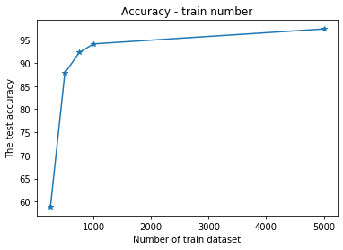

```python
num = [250, 500, 750, 1000, 5000]
accuracy = [58.89, 87.79, 92.25, 94.12, 97.34]
plt.figure()
plt.plot(num, accuracy,'*-')
plt.xlabel("Number of train dataset")
plt.ylabel("The test accuracy")
plt.title("Accuracy - train number")
plt.show()
```